# Synthetic Data Simulation Results

Alan Hubbard

2024-04-08

# Simulation Code

```r
generate_data_simple <- function(N,Xranges=c(-1,1,-1,1),betaA=c(0,0.1,-0.4),
                                 betaY0=c(0,1,2,-1),betaC=c(1,7/5,5,3),sdy=1){
  # A simple data generating process
  X1 <- runif(N,Xranges[1],Xranges[2])
  X2 <- runif(N,Xranges[3],Xranges[4])
  pi0 <- plogis(betaA[1]+betaA[2]*X1*X2+betaA[3]*X1)
  A <- rbinom(N,1,prob=pi0)
  muY0 <- betaY0[1]+betaY0[2]*X1*X2 + betaY0[3]*X2^2 +betaY0[4]*X1
  CATE <- betaC[1]*X1^2*(X1+betaC[2]) + (betaC[3]*X2/betaC[4])^2
  muY = muY0+A*CATE
  Y <- rnorm(N,sd=sdy,mean= muY)
  return(tibble(X1=X1,X2=X2,A=A,Y=Y))
}
```

# Synthetic data simulation details

We have created a structure to

_1. Simulate complex data from known distributions

```
_a. Can be cross-sectional,

_b. longitudinal,

_c. have missing data, etc.
```

_2. Define a set of parameters we wish to estimate and derive inference from the synthetic data

```
_a. Marginal parameters, like means

_b. Regression estimates for working models

_c. Causal parameters based on known causal model
```

# Simulation Structure

Investigate the performance of competing methods for synthetic data by:

_1. Simulate the data.

_2. Estimate the data-generating distribution using different methods (HAL, SuperLearner, etc.): looking at additional methods.

_3. Synthethesize the data from the estimated DGDs based on competing methods.

_4. Repeat 1-3 1000 times.

_5. Evaluate the comparison of the distribution of synthetic data-based results to those based on the actual data.

# X-Sectional Data Example

# Parameters of Interest

- Simple ones
  - $P(A=1)$
  - $EY$
- Standard Regression parameters
  - Coefficients in working model: $b_0+b_1*W_1+b_2*W_2+b_3*A$
- Causal parmaters estimated with (targeted) machine learning
  - $ATE=E(E(Y|A=1,W)-E(Y|A=0,W))$

# Methods for generating Synthetic Data

- Highly adaptive lasso (HAL)
- SuperLearner
- Compare estimates using synthetic data to those based on the data behind synthetic data

# Estimators used to get parameters from synthetic (and actual) data

- Simple parameters - simple averages
- Coefficients - ordinary least squares
- ATE - TMLE with SL
- Evaluations: bias, variance, MSE and coverage

# Straightforward issues with inference from Synthetic Data

- If the methods used to estimate the parameters that define the model for the DGD are unbiased, synthetic data based on them will not be.
- For example, if my model is $X \sim N(\mu,\sigma)$
- Want to synthesize data based on a sample $X_i, i=1,...,n$
- Generate synthetic data from $N(\bar{X},\sigma): X^*_i, i=1,...n$
- Estimate $\mu$ with $\bar{X}^*$
- MSE of estimate based on synthetic data is: $MSE (\bar{X}^*)=E(\bar{X}^*-\bar{X})^2+E(\bar{X}-\mu)^2$
- To get good coverage in this simple conrext, would increase the margin of error in confidence intervals by a factor of $\sqrt{2}: \hat{\theta} \pm \sqrt{2}*1.96*SE(\hat{\theta})$.
- Could also generate a synthetic data sample that is very large relative to the size of the original data to get estimates, but based inference (calculate standard erros) on a synthetic sample the same size as the original data.

# Results

# $P(A=1)$

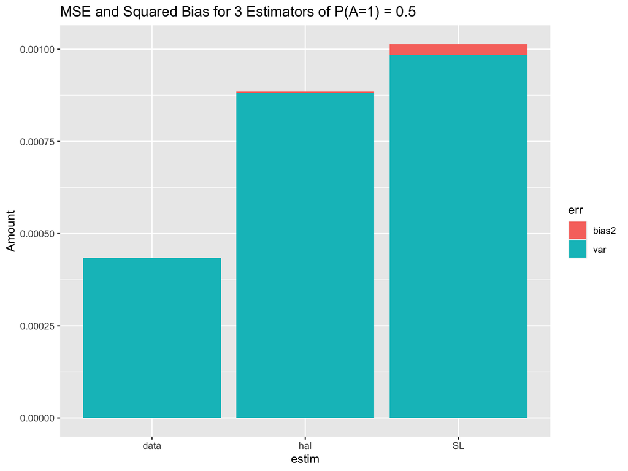

# $EY$

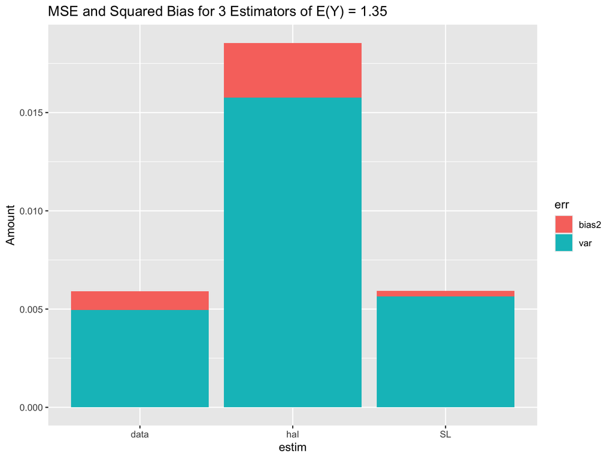

# Regression coefficients from working model

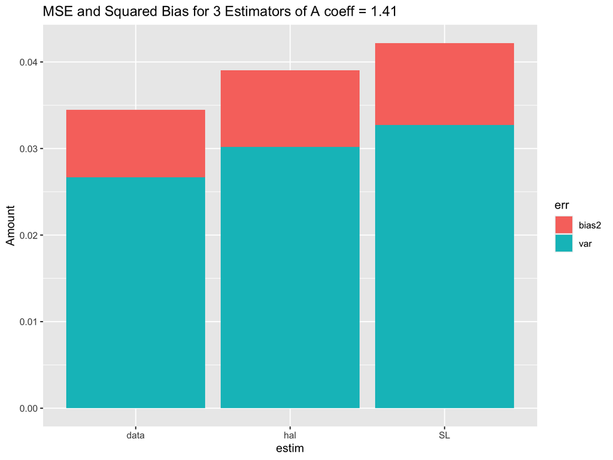

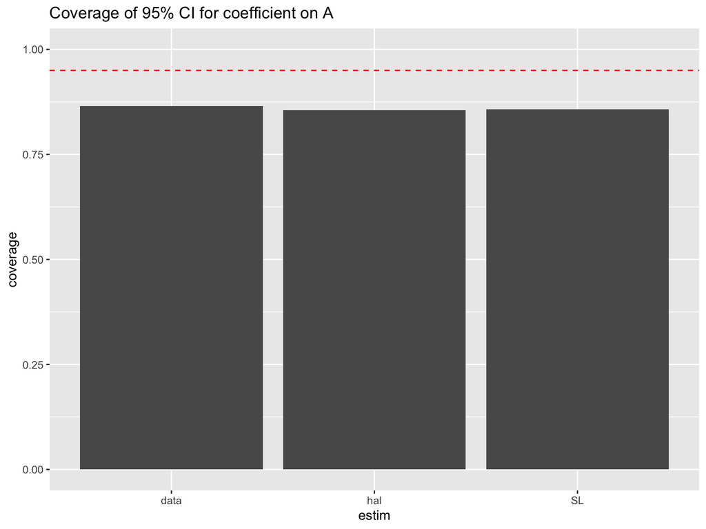

# ATE

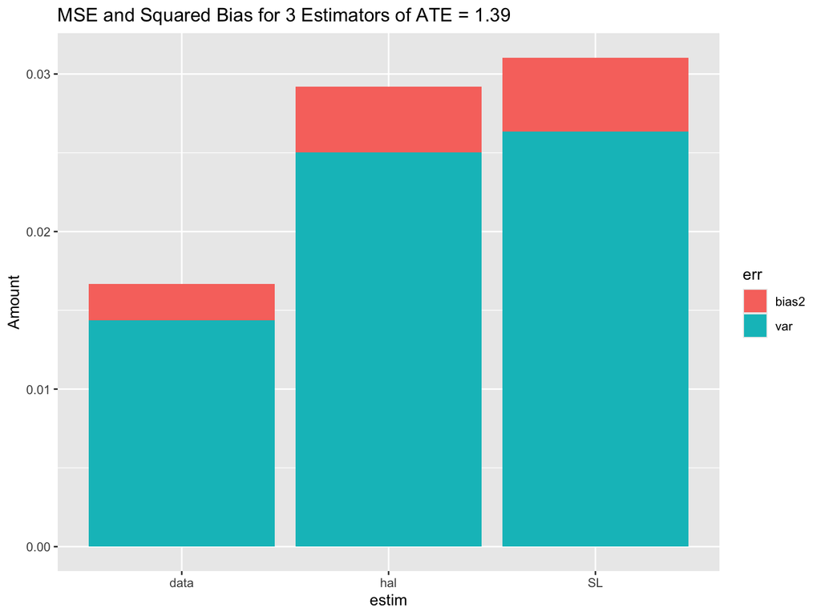

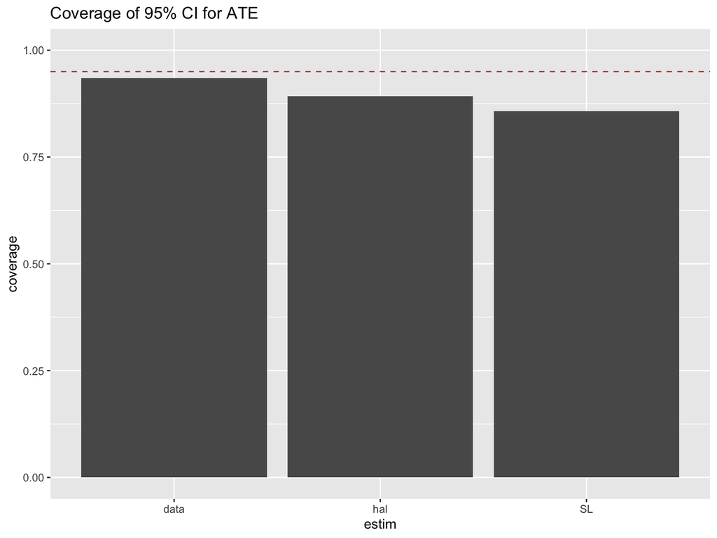

# Other work in progress

- More complex simulations that mimic N3C data (e.g., missing data, more complex models based on long Covid N3C data)
- Methods for obscuring baseline covariates for privacy
  - Estimating joint distribution of discretized baseline covariates
  - Apply required coarsening of identifying variables (age, etc.)
- Comparisons to existing synthetic data algorithms available (usually very similar in framework, but use more arbitrary modeling assumptions)
- Develop general algorithm that works directly on HAL objects and users can querry parameters by providing functions which operate on HAL objects that contain DGD components.
- Exploring generative AI but skeptical they are applicable to sample sizes of data based on N3C without having a pre-trained model on similar data.